# README

Loes Soetens

20 juni 2016

# *Contactviz*: visualization of contact tracing data

*Contactviz* implements new methods for the exploration and analysis of contact tracing data, with taking into account that the data are censored.

## Installing *Contactviz*

To install the development version from github:

```r
library(devtools)
install_github("lsoetens/Contactviz")
```

Then, to load the package, use:

```r
library("Contactviz")
```

The package contains a shiny-app, which can subsequently be run with:

```r
runContactviz()
```

The shiny-app `Contactviz` is available via a user-friendly web interface, running locally on the default web browser.

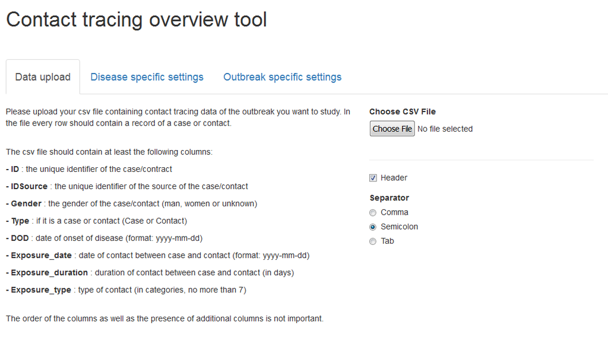

The first tab ‘data upload’ specifies the data requirements.

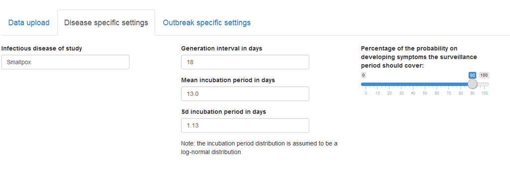

The second tab is concerned with disease specific settings, such as the parameters on the incubation period or generation interval. It also contains a slider for setting how strict you want to be in following-up contacts.

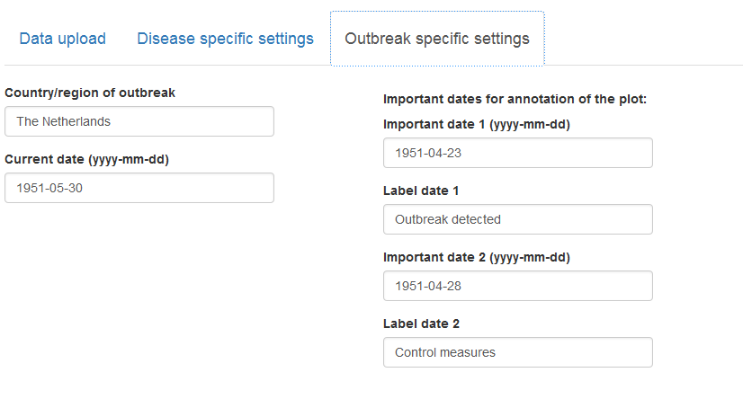

The third tab is on outbreak specific settings. The data of analysis should be specified, and there is the option of marking important dates in the outbreak.

After uploading the data and setting the specific settings, a plot is shown at the bottom of the screen.

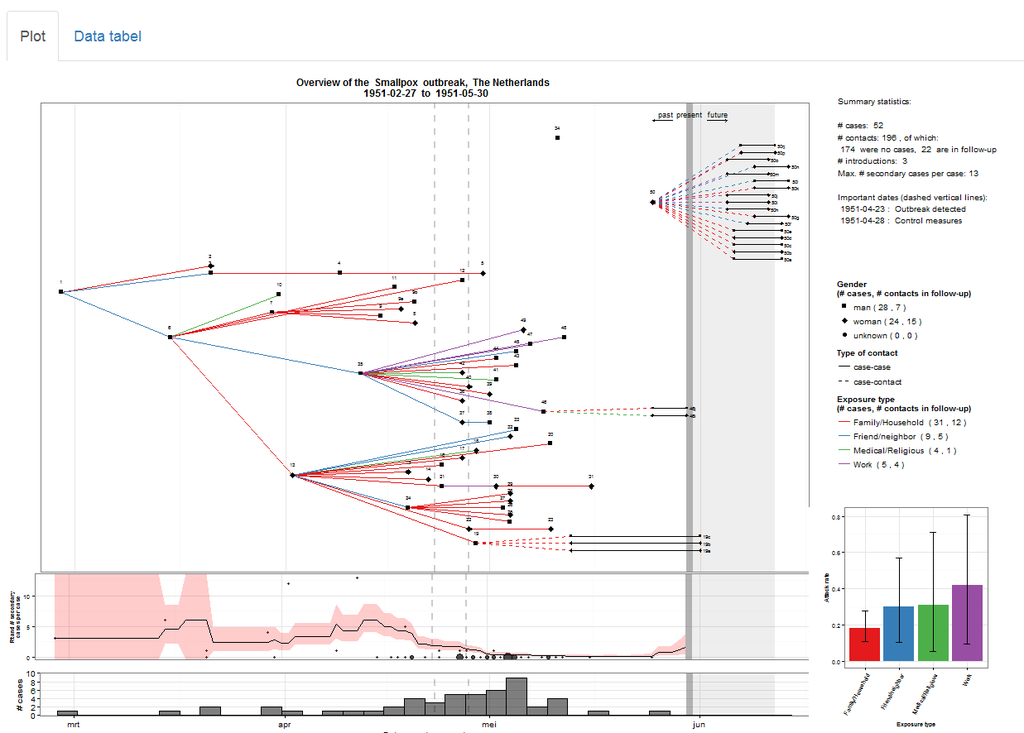

This plot is the main output. It contains a time-oriented network of all cases (squares and diamonds) and contacts still in follow-up (horizontal bars); the evolution of Rt during the outbreak; an epicurve; and the estimations of the attack rates for various exposure routes.

Next to this plot, the data itself can also be viewed in the other output- tab.

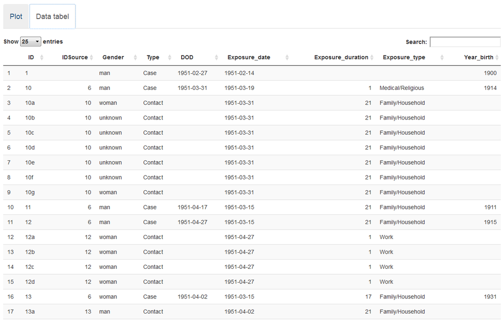